# HW7

## Домашнее задание 7. Докинг низкомолекулярных лигандов в структуру белка.

### Горохов Никита

Подключим необходимые модули

```python
import numpy as np
import copy

# Отображение структур
import IPython.display
import ipywidgets
from IPython.display import display,display_svg,SVG,Image

# Open Drug Discovery Toolkit
import oddt
import oddt.docking
import oddt.interactions

# Органика
from rdkit.Chem import Draw
from rdkit.Chem.Draw import IPythonConsole

import pmx # Модуль для манипулирования pdb
```

Загрузим структуру белка из предыдущего задания.

```python
pdb=pmx.Model('../Homework 6/chicken_ligand.B99990001.pdb')

for r in pdb.residues[135:]:
    print r #посмотрим остатки
```

```
<Molecule: id = 136 name = THR chain_id =    natoms = 7>
<Molecule: id = 137 name = ASP chain_id =    natoms = 8>
<Molecule: id = 138 name = VAL chain_id =    natoms = 7>
<Molecule: id = 139 name = GLN chain_id =    natoms = 9>
<Molecule: id = 140 name = ALA chain_id =    natoms = 5>
<Molecule: id = 141 name = TRP chain_id =    natoms = 14>
<Molecule: id = 142 name = ILE chain_id =    natoms = 8>
<Molecule: id = 143 name = ARG chain_id =    natoms = 11>
<Molecule: id = 144 name = GLY chain_id =    natoms = 4>
<Molecule: id = 145 name = CYS chain_id =    natoms = 6>
<Molecule: id = 146 name = ARG chain_id =    natoms = 11>
<Molecule: id = 147 name = LEU chain_id =    natoms = 9>
<Molecule: id = 148 name = NAG chain_id =    natoms = 14>
<Molecule: id = 149 name = NAG chain_id =    natoms = 14>
<Molecule: id = 150 name = NDG chain_id =    natoms = 15>
```

```python
# создание объектов белок и лиганда
newpdb = pdb.copy()
for r in newpdb.residues[-3:]:
    newpdb.remove_residue(r)
lig = pdb.copy()
del lig.residues[:-3]
```

Найдем геометрический центр лиганда. Нужно найти среднее значение по каждой из координат. То есть посчитать сумму и разделить на количество.

```python
center_ligand = np.zeros(3)
for a in lig.atoms:
    center_ligand += a.x # сумма
center_ligand /= len(lig.atoms)
newpdb.writePDB("new_prot.pdb")
```

**Подготовка белка для докинга**

```python
prot = oddt.toolkit.readfile('pdb','new_prot.pdb').next()

prot.OBMol.AddPolarHydrogens()
prot.OBMol.AutomaticPartialCharge()

print 'is it the first mol in 1lmp is protein?',prot.protein,':) and MW of this mol is:', prot.molwt
```

```
is it the first mol in 1lmp is protein? False :) and MW of this mol is: 16230.43242
```

**Лиганды для докинга**

```python
smiles = ['c1cccc(O)c1', 'c1c(O)ccc(O)c1','c1(O)cc(c2ccccc2)cc(O)c1']
mols= []
images =[]

for s in smiles:
    m = oddt.toolkit.readstring('smi', s)
    if not m.OBMol.Has3D():
        m.make3D(forcefield='mmff94', steps=150)
        m.removeh()
        m.OBMol.AddPolarHydrogens()

    mols.append(m)
    ###with print m.OBMol.Has3D() was found that:
    ### deep copy needed to keep 3D , write svg make mols flat
    images.append((SVG(copy.deepcopy(m).write('svg'))))

display_svg(*images)
```

[figure not shown]

**Докинг**

Параметры запуска:

- *--center_x, --center_y, --center_z* - это координаты центра докинг бокса, куда будет вставлен лиганд
- *--size_x, size_y, size_z* - это размеры бокса (куба) в которую будет подставлен лиганд
- *--cpu* - количество процессоров
- *--exhaustiveness* - параметр алгоритма Autodock Vina
- *--num_modes* - количество пристыкованных позиций (docked poses) (9 - max, из-за ограничения Autodock Vina).
- *--energy_range* - ограничение на разброс энегрии

```python
#create docking object
dock_obj= oddt.docking.AutodockVina.autodock_vina(
    protein=prot, size=(20,20,20), center=center_ligand,
    executable='/usr/bin/vina', autocleanup=True, num_modes=9)

print dock_obj.tmp_dir
print " ".join(dock_obj.params) # Опишите выдачу
```

```
/tmp/autodock_vina_bCdsJd
--center_x 45.45585059422755 --center_y 31.117998302207113 --center_z 23.200477928692703 --size_x 20 --size_y 20 --size_z 20 --cpu 1 --exhaustiveness 8 --num_modes 9 --energy_range 3
```

```python
res = dock_obj.dock(mols,prot)
```

**Результаты докинга**

```python
import pandas as pd

formulas = [x.formula for x in res]
affinities = [x.data["vina_affinity"] for x in res]
rmsd = [x.data["vina_rmsd_ub"] for x in res]
names = [x.residues[0].name for x in res]

df = pd.DataFrame(
    {
        "formula": formulas,
        "affinity": affinities,
        "rmsd": rmsd,
        "name": names
    })
df = df.sort_values(by=['affinity'], ascending=[1])
df
```

|  | affinity | formula | name | rmsd |
| --- | --- | --- | --- | --- |
| 8 | -3.8 | C6H6O | UNL | 17.198 |
| 7 | -3.8 | C6H6O | UNL | 16.365 |
| 17 | -3.9 | C6H6O2 | UNL | 15.520 |
| 6 | -3.9 | C6H6O | UNL | 16.799 |
| 15 | -4.0 | C6H6O2 | UNL | 15.475 |
| 16 | -4.0 | C6H6O2 | UNL | 15.416 |
| 4 | -4.0 | C6H6O | UNL | 16.377 |
| 3 | -4.0 | C6H6O | UNL | 16.297 |
| 5 | -4.0 | C6H6O | UNL | 3.246 |
| 2 | -4.1 | C6H6O | UNL | 2.453 |
| 10 | -4.1 | C6H6O2 | UNL | 4.265 |
| 11 | -4.1 | C6H6O2 | UNL | 4.632 |
| 12 | -4.1 | C6H6O2 | UNL | 3.488 |
| 14 | -4.1 | C6H6O2 | UNL | 15.301 |
| 13 | -4.1 | C6H6O2 | UNL | 4.308 |
| 9 | -4.2 | C6H6O2 | UNL | 0.000 |
| 1 | -4.5 | C6H6O | UNL | 3.432 |
| 0 | -4.9 | C6H6O | UNL | 0.000 |
| 24 | -5.8 | C12H10O2 | UNL | 7.016 |
| 25 | -5.8 | C12H10O2 | UNL | 15.192 |
| 26 | -5.8 | C12H10O2 | UNL | 15.037 |
| 22 | -5.9 | C12H10O2 | UNL | 5.597 |
| 23 | -5.9 | C12H10O2 | UNL | 5.768 |
| 21 | -6.0 | C12H10O2 | UNL | 5.196 |
| 18 | -6.1 | C12H10O2 | UNL | 0.000 |
| 19 | -6.1 | C12H10O2 | UNL | 2.190 |
| 20 | -6.1 | C12H10O2 | UNL | 5.072 |

**Анализ докинга**

```python
for i,r in enumerate(res):
    hbs = oddt.interactions.hbonds(prot,r)
    stack= oddt.interactions.pi_stacking(prot,r)
    phob = oddt.interactions.hydrophobic_contacts(prot,r)
```

**Визуализация**

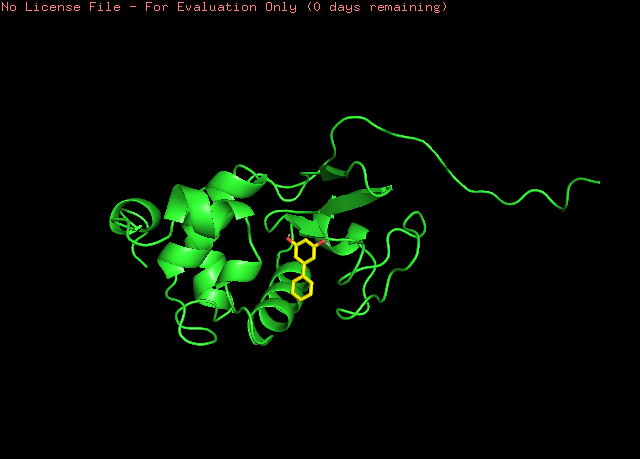

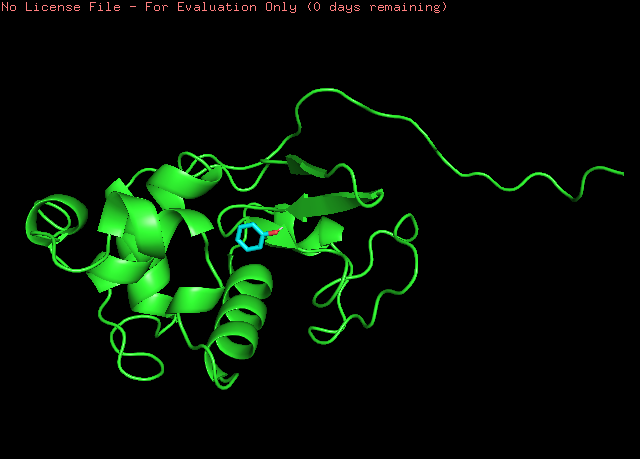

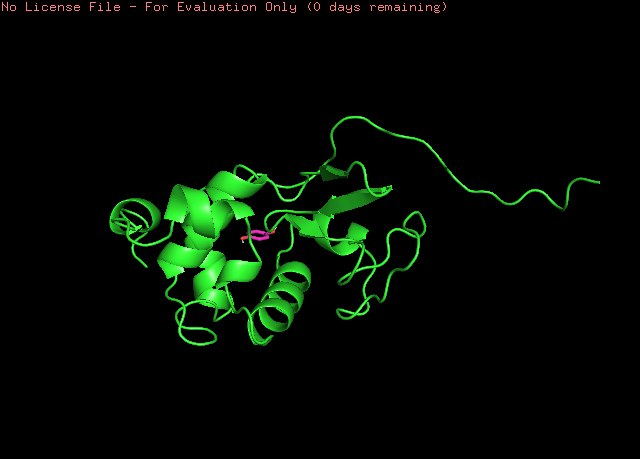

```python
res[8].write(filename='r-C6H6O.pdb', format='pdb', overwrite=True)
res[17].write(filename='r-C6H6O2.pdb', format='pdb', overwrite=True)
res[24].write(filename='r-C12H10O2.pdb', format='pdb', overwrite=True)

display(Image(filename="r-C12H10O2.png"),
        Image(filename="r-C6H6O.png"),
        Image(filename="r-C6H6O2.png"))
```

### Задание

Теперь перейдем к самому заданию.

*NAG* содержит в себе *СH3C(=O)NH* группу. Создайте лиганды где метильный радикал этой группы будет заменён на :

- OH
- NH3+
- H
- Ph
- COO-

Первым делом найдем Canonical SMILES формулу *NAG* (N-Ацетилглюкозамин).

Формула ([PubChem](https://pubchem.ncbi.nlm.nih.gov/compound/24139#section=InChI-Key)) - CC(=O)NC1C(C(C(OC1O)CO)O)O

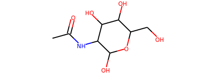

```python
from rdkit import Chem
from rdkit.Chem import AllChem
nag = Chem.MolFromSmiles('CC(=O)NC1C(C(C(OC1O)CO)O)O')
AllChem.Compute2DCoords(nag)
display(nag)
```

Составим Canonical SMILE формулы для лиганд

- **OH**: OC(=O)NC1C(C(C(OC1O)CO)O)O
- **NH3+**: [NH3+]C(=O)NC1C(C(C(OC1O)CO)O)O
- **H**: C(=O)NC1C(C(C(OC1O)CO)O)O
- **Ph**: C1=CC=[C]C=C1C(=O)NC1C(C(C(OC1O)CO)O)O
- **COO-**: [O-]C(=O)C(=O)NC1C(C(C(OC1O)CO)O)O

Повторим все тоже самое, только с новыми лигандами.

```python
smiles = ['OC(=O)NC1C(C(C(OC1O)CO)O)O',
          '[NH3+]C(=O)NC1C(C(C(OC1O)CO)O)O',
          'C(=O)NC1C(C(C(OC1O)CO)O)O',
          'C1=CC=[C]C=C1C(=O)NC1C(C(C(OC1O)CO)O)O',
          '[O-]C(=O)C(=O)NC1C(C(C(OC1O)CO)O)O']
mols= []
images =[]

for s in smiles:
    m = oddt.toolkit.readstring('smi', s)
    if not m.OBMol.Has3D():
        m.make3D(forcefield='mmff94', steps=150)
        m.removeh()
        m.OBMol.AddPolarHydrogens()

    mols.append(m)
    ###with print m.OBMol.Has3D() was found that:
    ### deep copy needed to keep 3D , write svg make mols flat
    images.append((SVG(copy.deepcopy(m).write('svg'))))

display_svg(*images)
```

[figure not shown]

```python
#create docking object
dock_obj= oddt.docking.AutodockVina.autodock_vina(
    protein=prot, size=(20,20,20), center=center_ligand,
    executable='/usr/bin/vina', autocleanup=True, num_modes=9)

print dock_obj.tmp_dir
print " ".join(dock_obj.params) # Опишите выдачу
```

```
/tmp/autodock_vina_zCWl6L
--center_x 45.45585059422755 --center_y 31.117998302207113 --center_z 23.200477928692703 --size_x 20 --size_y 20 --size_z 20 --cpu 1 --exhaustiveness 8 --num_modes 9 --energy_range 3
```

```python
res = dock_obj.dock(mols,prot)
```

```python
import pandas as pd

translate = {
    "C7H13NO7": "OH",
    "C7H15N2O6": "NH3+",
    "C7H13NO6": "H",
    "C13H17NO6": "Ph",
    "C8H13NO8": "COO-"
}

formulas = [x.formula for x in res]
ligands = [translate[x] for x in formulas]
affinities = [x.data["vina_affinity"] for x in res]
rmsd = [x.data["vina_rmsd_ub"] for x in res]
names = [x.residues[0].name for x in res]

df = pd.DataFrame(
    {
        "formula": formulas,
        "affinity": affinities,
        "rmsd": rmsd,
        "name": names,
        "ligand": ligands
    })
df = df.sort_values(by=['affinity'], ascending=[1])
df
```

|  | affinity | formula | ligand | name | rmsd |
| --- | --- | --- | --- | --- | --- |
| 44 | -4.2 | C8H13NO8 | COO- | UNL | 11.876 |
| 17 | -4.3 | C7H15N2O6 | NH3+ | UNL | 11.288 |
| 16 | -4.3 | C7H15N2O6 | NH3+ | UNL | 11.574 |
| 15 | -4.3 | C7H15N2O6 | NH3+ | UNL | 13.124 |
| 14 | -4.3 | C7H15N2O6 | NH3+ | UNL | 2.909 |
| 7 | -4.4 | C7H13NO7 | OH | UNL | 11.850 |
| 8 | -4.4 | C7H13NO7 | OH | UNL | 12.096 |
| 5 | -4.5 | C7H13NO7 | OH | UNL | 4.805 |
| 6 | -4.5 | C7H13NO7 | OH | UNL | 11.395 |
| 12 | -4.6 | C7H15N2O6 | NH3+ | UNL | 11.983 |
| 13 | -4.6 | C7H15N2O6 | NH3+ | UNL | 11.622 |
| 4 | -4.6 | C7H13NO7 | OH | UNL | 10.767 |
| 3 | -4.6 | C7H13NO7 | OH | UNL | 13.125 |
| 35 | -4.7 | C13H17NO6 | Ph | UNL | 14.176 |
| 43 | -4.7 | C8H13NO8 | COO- | UNL | 12.079 |
| 2 | -4.8 | C7H13NO7 | OH | UNL | 5.869 |
| 42 | -4.8 | C8H13NO8 | COO- | UNL | 12.274 |
| 41 | -4.9 | C8H13NO8 | COO- | UNL | 5.843 |
| 34 | -4.9 | C13H17NO6 | Ph | UNL | 14.039 |
| 26 | -4.9 | C7H13NO6 | H | UNL | 3.522 |
| 25 | -5.0 | C7H13NO6 | H | UNL | 3.748 |
| 33 | -5.0 | C13H17NO6 | Ph | UNL | 14.435 |
| 23 | -5.0 | C7H13NO6 | H | UNL | 2.437 |
| 24 | -5.0 | C7H13NO6 | H | UNL | 4.402 |
| 40 | -5.0 | C8H13NO8 | COO- | UNL | 6.109 |
| 39 | -5.1 | C8H13NO8 | COO- | UNL | 12.046 |
| 32 | -5.1 | C13H17NO6 | Ph | UNL | 13.571 |
| 22 | -5.1 | C7H13NO6 | H | UNL | 1.901 |
| 31 | -5.2 | C13H17NO6 | Ph | UNL | 13.218 |
| 38 | -5.2 | C8H13NO8 | COO- | UNL | 5.894 |
| 21 | -5.3 | C7H13NO6 | H | UNL | 2.353 |
| 1 | -5.3 | C7H13NO7 | OH | UNL | 4.733 |
| 20 | -5.4 | C7H13NO6 | H | UNL | 4.487 |
| 19 | -5.4 | C7H13NO6 | H | UNL | 3.712 |
| 11 | -5.5 | C7H15N2O6 | NH3+ | UNL | 5.123 |
| 18 | -5.7 | C7H13NO6 | H | UNL | 0.000 |
| 10 | -5.7 | C7H15N2O6 | NH3+ | UNL | 3.971 |
| 9 | -5.7 | C7H15N2O6 | NH3+ | UNL | 0.000 |
| 29 | -5.8 | C13H17NO6 | Ph | UNL | 6.705 |
| 30 | -5.8 | C13H17NO6 | Ph | UNL | 6.892 |
| 0 | -5.9 | C7H13NO7 | OH | UNL | 0.000 |
| 37 | -6.0 | C8H13NO8 | COO- | UNL | 6.196 |
| 36 | -6.2 | C8H13NO8 | COO- | UNL | 0.000 |
| 28 | -6.8 | C13H17NO6 | Ph | UNL | 2.398 |
| 27 | -6.9 | C13H17NO6 | Ph | UNL | 0.000 |

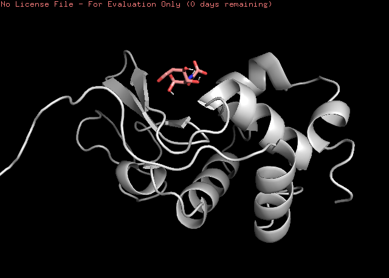

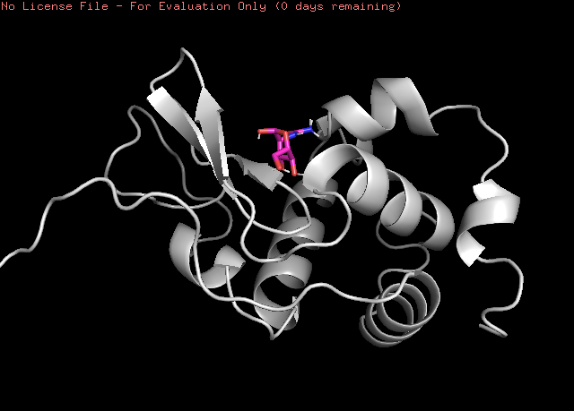

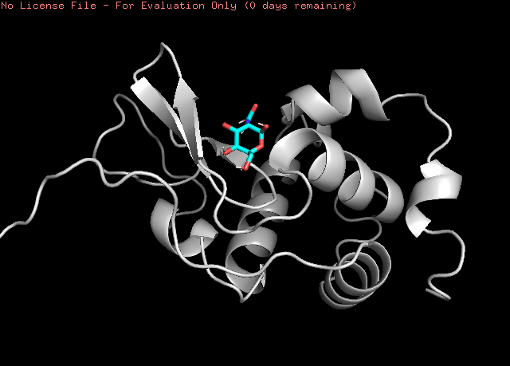

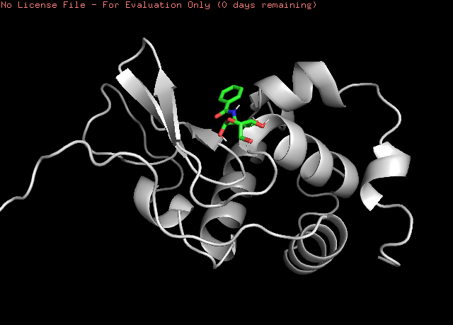

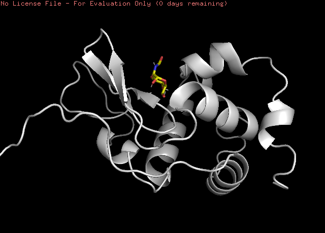

```python
res[44].write(filename='r-COO-.pdb', format='pdb', overwrite=True)
res[17].write(filename='r-NH3+.pdb', format='pdb', overwrite=True)
res[7].write(filename='r-OH.pdb', format='pdb', overwrite=True)
res[35].write(filename='r-ph.pdb', format='pdb', overwrite=True)
res[26].write(filename='r-H.pdb', format='pdb', overwrite=True)

display(Image(filename="r-COO-.png"),
        Image(filename="r-NH3+.png"),
        Image(filename="r-OH.png"),
        Image(filename="r-ph.png"),
        Image(filename="r-H.png"))
```

Предложите методы из статьи про ODDT (пакет Sklearn), которые можно было бы использовать в Вашем упражнении.

Рассмотрим примеры из статьи ([oddt](https://jcheminf.biomedcentral.com/articles/10.1186/s13321-015-0078-2)):

- Пример 1) В этом примере сначала фильтруются лиганды, затем выполняется докинг с параметрами по умолчанию. И после этого применяют две скоринг функции для генерации лиганд-рецепторных конформаций. После этого перерасчитанные результаты записываются в итоговую таблицу.
- Пример 2) В этом примере происходит попытка использования элементов машинного обучения для поулчения наилучшей модели. Было построенно несколько моделей (данные PDBbin, модели: RF, SVM, NN, MLR)
- Пример 3) Не особо понятно)

**Вывод**: К нашей задаче можно применить переоценку из первого примера.